# 1 Context

Flow injection analysis (FIA) is becoming more and more used in the context of high-throughput profiling, because of an increased resolution of mass spectrometers (HRMS). The data produced however are complex and affected by matrix effect which makes their processing difficult. The **proFIA** bioconductor package provides the first workflow to process FIA-HRMS raw data and generate the peak table. By taking into account the high resolution and the information of matrix effect available from multiple scans, the algorithms are robust and provide maximum information about ions m/z and intensitie using the full capability of modern mass spectrometers.

# 2 Structure

The first part of this vignette give a quick overview of the **proFIA** main workflow and the second part discuss the important parameters and gives some hint about parameters tuning using the plot offered by **proFIA**

# 3 Workflow

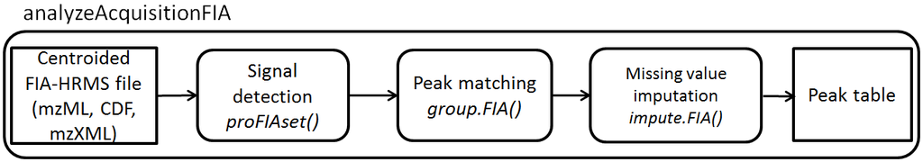

*proFIA* workflow

The first step generates the `proFIAset` object, which will be further processed during the workflow. The object contains initial information about the sample and the classes (when subdirectories for the raw data are present), as well as all results froom the processing (e.g., detected peaks, grouping, etc.). At each step, the data quality can be checked by a graphical overview using the `plot` function. For convenience, the 3 processing functions and methods from the workflow (`proFIAset`, `group.FIA`, and `impute.FIA`) have been wrapped into a single `analyzeAcquisitionFIA` function. The final *dataMatrix* can be exported, as well as the 2 supplementary tables containing the *sampleMetadata* and the *variableMetadata*.

# 4 The **plasFIA** data package

# 5 Hands-on

## 5.1 Peak detection with `proFIAset`

We first load the two packages containing the software and the dataset:

```r
# loading the packages
library(proFIA)
library(plasFIA)
```

```r
# finding the directory of the raw files
path <- system.file(package="plasFIA", "mzML")
list.files(path)
```

```
## [1] "C100A.mzML" "C100B.mzML" "C10A.mzML"  "C10B.mzML"  "C1A.mzML"
## [6] "C1B.mzML"
```

The first step of the workflow is the **proFIAset** function which takes as input the path to the raw files. This function performs noise model building, followed by m/z strips detection and filtering. The important parameters to keep in mind are:

- `noiseEstimation` (logical): shall noise model be constructed to filter signal? (recommended).
- `ppm` and `dmz` (numeric): maximum deviation between scans during strips detection in ppm. If the deviation in absolute in mz is lower than dmz, *dmz* is taken over *ppm* to account for low masses bias. More information about the tuning of this parameters is given in the Tuning proFIA parameters section
- `parallel` (logical): shall parallel computation be used. You can define which sort of parallelism you want to use using the [BioCParallel](http://bioconductor.org/packages/release/bioc/html/BiocParallel.html) package.

Note: As all files need to be processed 2 times, one for noise estimation and one for model estimation, this step is the most time consuming of the workflow.

```r
# defining the ppm parameter adapted to the Orbitrap Fusion
ppm <- 2

# performing the first step of the workflow
plasSet <- proFIAset(path, ppm=ppm, parallel=FALSE)
```

[output not shown]

[output cut: 5662 more lines]

[output not shown]

[output not shown]

[output cut: 4786 more lines]

[output not shown]

[output not shown]

[output cut: 2956 more lines]

[output not shown]

[output not shown]

[output cut: 2059 more lines]

[output not shown]

[output not shown]

[output cut: 3880 more lines]

[output not shown]

[output not shown]

[output cut: 4774 more lines]

[output not shown]

The quality of peak detection can be assessed by using the `plotRaw` method to visualize the corresponding areas in the raw data.

```r
# loading the spiked molecules data frame
data("plasMols")

# plotting the raw region aroung the Diphenhydramine mass signal
plasMols[7,]
```

```
##    formula           names classes     mass mass_M+H
## 7 C17H21NO Diphenhydramine Benzene 255.1623 256.1696
```

```
## Create profile matrix with method 'bin' and step 1 ... OK
```

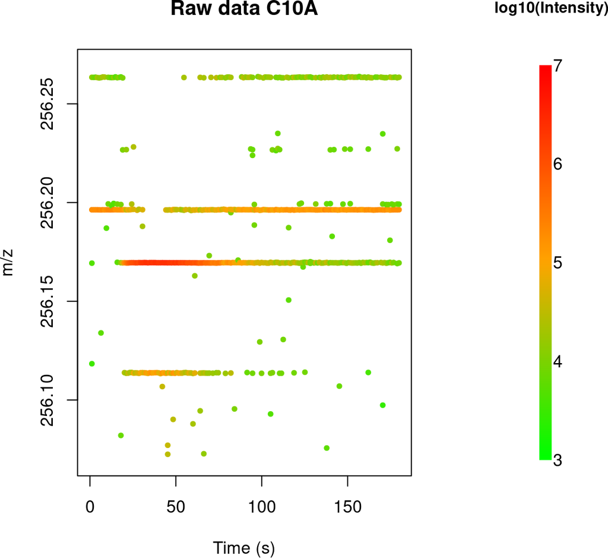

```r
mzrange <- c(plasMols[7,"mass_M+H"]-0.1,plasMols[7,"mass_M+H"]+0.1)
plotRaw(plasSet, type="r", sample=3, ylim=mzrange, size=0.6)
```

In the example above, we see that a signal at 256.195 m/z corresponding to the solvent has been correctly discarded by **proFIA**.

```
## Create profile matrix with method 'bin' and step 1 ... OK
```

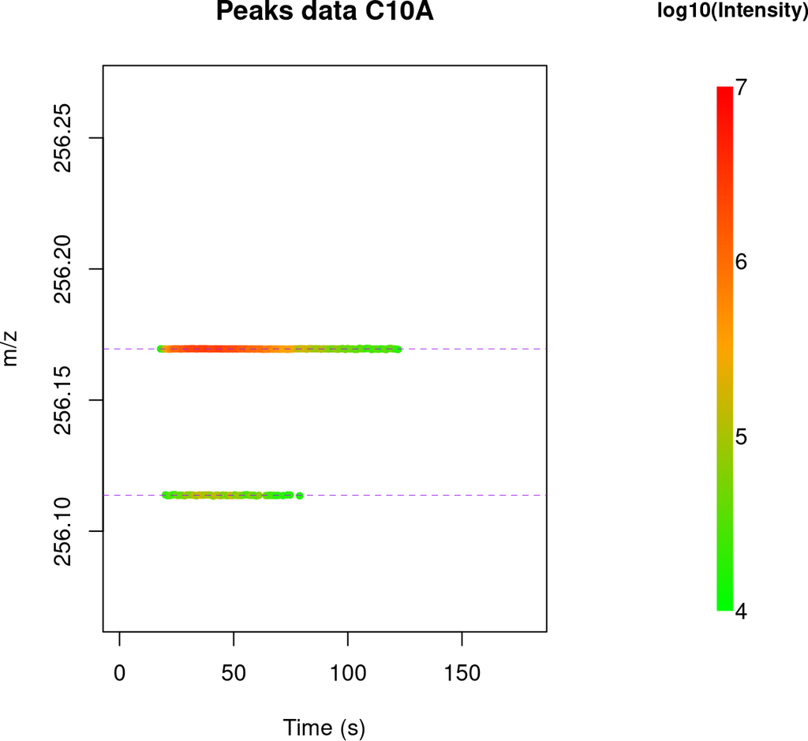

```r
# plotting the filter Dipehnhydramine region.
plotRaw(plasSet, type="p", sample=3, ylim=mzrange, size=0.6)
```

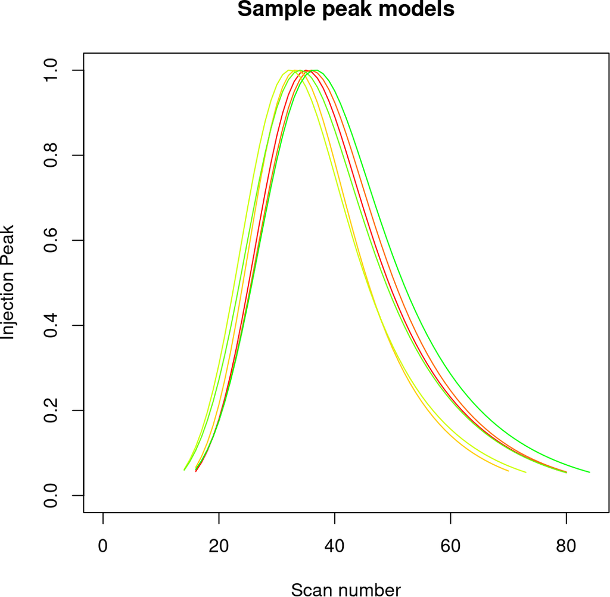

```r
# plotting the injection peak
plotSamplePeaks(plasSet)
```

## 5.2 Peak grouping with `group.FIA`

The second step of the workflow consists in matching the signals between the samples. The `group.FIA` methods uses an estimation of the density in the mass dimension. The two important parameters are:

- `ppmGroup` and `dmzGroup` (numeric): accuracy of the mass spectrometer; must be inferior or equal to the corresponding value in `proFIAset`
- `fracGroup` (numeric): minimum fraction of samples with detected peaks in at least one class for a group to be created.

```r
# selecting the parameters
ppmgroup <- 1

# due to the experimental design, sample fraction was set to 0.2
fracGroup <- 0.2

# grouping
plasSet <- group.FIA(plasSet, ppmGroup=ppmgroup, fracGroup=fracGroup)
```

```
##
##  769  groups have been done .
```

Some help on the tuning of these parameters may be found in the Tuning proFIA parameters section. The groups may be visualized using the **plotFlowgrams** function, which take as input a mass and a ppm tolerance, or an index.

[output not shown]

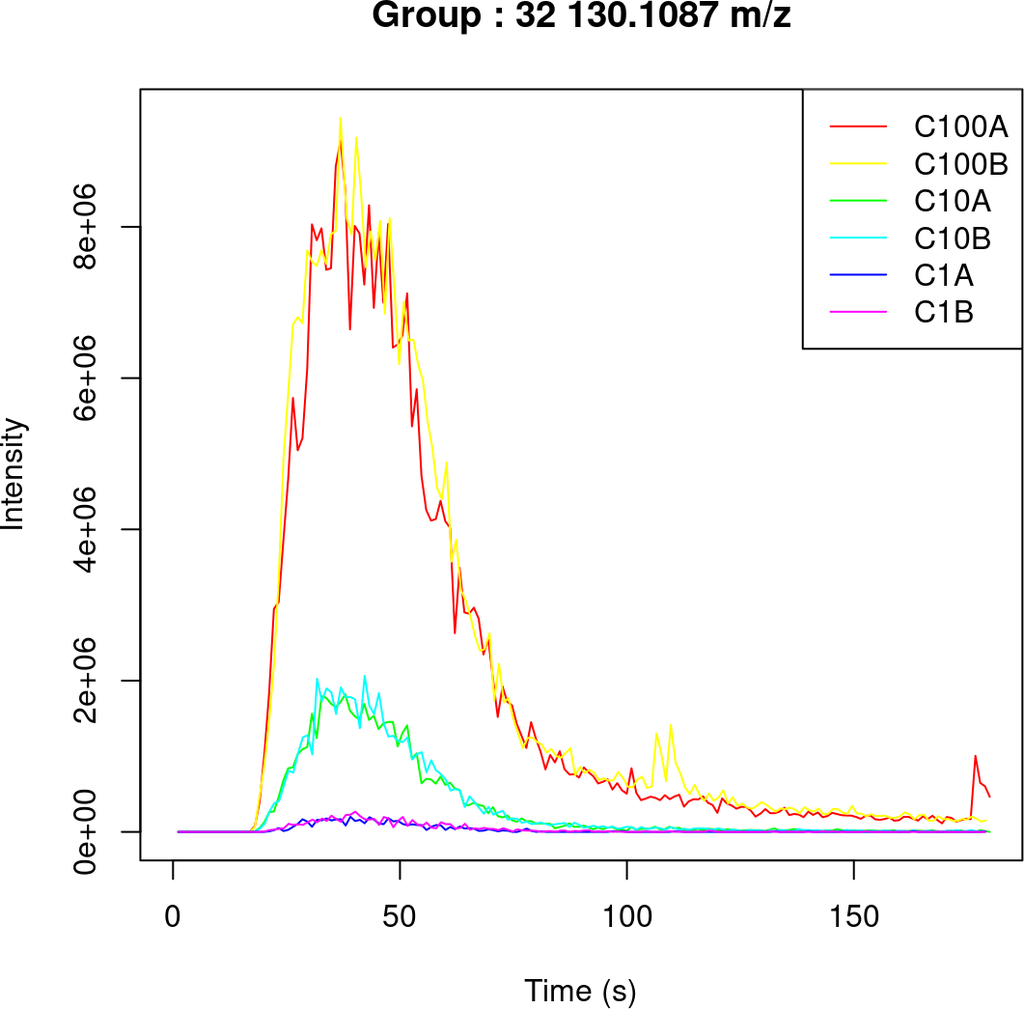

```r
#plotting the EICs of the parameters.
plotFlowgrams(plasSet,mz=plasMols[4,"mass_M+H"])
```

At this stage, it is possible to check whether a molecule (i.e., a group) has been detected in the dataset by using the `findMzGroup` method.

```r
# Searching for match group with 2 ppm tolerance
lMatch <- findMzGroup(plasSet,plasMols[,"mass_M+H"],tol=3)

# index of the 40 molecules which may be used with plotEICs
molFound <- data.frame(names=plasMols[,"names"],found=lMatch)
head(molFound)
```

```
##                          names found
## 1            Acetyl-L-carnitin   170
## 2            3-Methylhistamine    24
## 3                    Panthenol   177
## 4                    Metformin    32
## 5                 Azelaic acid    NA
## 6 D-erythro-Dihydrosphingosine   349
```

```r
#Getting the molecules which are not detected
plasMols[which(is.na(lMatch)),]
```

```
##    formula                           names            classes     mass mass_M+H
## 5  C9H16O4                    Azelaic acid Dicarboxylic Acids 188.1049 189.1121
## 16 C6H10O5 3-Hydroxy-3-methylglutaric acid Dicarboxylic Acids 162.0528 163.0601
```

We see that molecules 5 and 16 were not found, which is coherent with their chemical classes as they are both Dicarboxylic Acids, which ionizes in negative modes.

## 5.3 Peak table with `makeDataMatrix`

The data matrix (*peak table*) can be built with the `makeDataMatrix` method: ion intensities can be computed either as the areas of the peaks (`maxo=F`) which is considered to be more robust, or as the maximum intensities (`maxo=T`).

```r
# building the data matrix
plasSet <- makeDataMatrix(plasSet, maxo=FALSE)
```

## 5.4 Imputation`impute.FIA`

```r
# k is supposed to be 3 at minimum, however here we have only 2 sample by class, the results of the imputation are therefore irrelevant.
k <- 3

#Missing values  imputation using kNN for truncated distribution by default.
plasSet <- impute.FIA(plasSet,k=k)

#Reinitializing the data matrix.
plasSet <- makeDataMatrix(plasSet)

#Imputation using random forest.
plasSet <- impute.FIA(plasSet,method="randomForest")

#As the dataset is ill-suited for missing value imputation we rebuild the data matrix.
plasSet <- makeDataMatrix(plasSet)
```

If you want to try the other imputation method, the data matrix shall be reset using the *makeDataMatrix* function.

## 5.5 Quality evaluation with `plot`

Plot allows you yo obtain a quick overview of the data, by plotting a summary of the acquisition :

```
## PCA
## 6 samples x 769 variables
## standard scaling of predictors
##       R2X(cum) pre ort
## Total    0.793   2   0
```

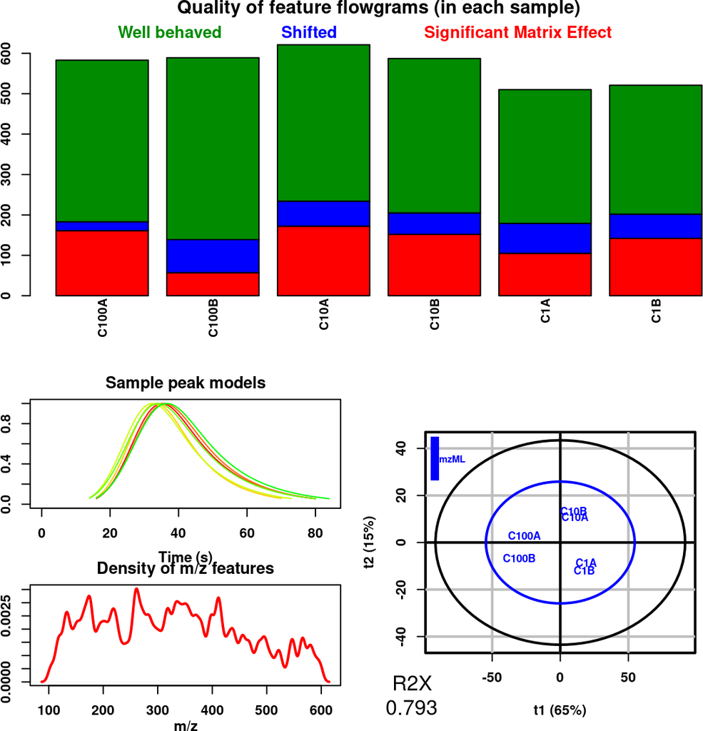

```r
plot(plasSet)
```

Note that all the graph are not all present at each step of the workflow. A small discussion of the content of each graph is given there :

- *Number of peaks* The upper graph show the number of relevant signal found in each sample, and labels the peaks in three cathegories. Peaks shifted in time correspond to peak which are outside the detected sample peak, and are probably results of rentention in the windows. Peak sufferient from shape distrosion are often affected by an heavy matrix effect, these 2 cathegories may indicate an issue in the acquisition. Well-behaved peak correspond to peak which follow the sample injection peak. For proFIA to perform optimally, the majority of these peak should be in this cathegory.
- *Injection Peaks* This give an overview of all the samples injections peaks regressed by proFIA, if the Flow Injection condition are the same, they should have similar shapes.
- *Density of m/z of found features* This plot is present after the goruping phase. It represent the density of the found features. This plot may allows the spotting of a missed band detection, resulting in no group at the end of the range of m/z, which can be caused by a wrong setting of the *dmz* or *ppm* parameters.
- *PCA* This graph is present after the data matrix construction. A simple ACP of the log intensity, allows you to quickly spot aberrant value in one acquisition. It is good to note that the plot is different after missing value imputation, as the data matrix changed.

## 5.6 Running the whole workflow with `analyzeAcquisitionFIA`

The whole workflow described previously can be run by a single call to the *analyzeAcquisitionFIA* function:

```r
#selecting the parameters
ppm <- 2
ppmgroup <- 1
fracGroup <- 0.2
k <- 3

# running the whole workflow in a single step
plasSet <- analyzeAcquisitionFIA(path, ppm=ppm, ppmGroup=ppmgroup, k=k,fracGroup = fracGroup,parallel=FALSE)

# Running the wholoe workflow in a single step, using parallelism
# with the BiocParallel package
plasSet <- analyzeAcquisitionFIA(path, ppm=ppm, ppmGroup=ppmgroup, k=k,fracGroup = fracGroup,parallel=TRUE)
```

## 5.7 Export

The processed data can be exported either as:

- A peak table in a format similar to the XCMS output.
- An *ExpressionSet* object (see the [Biobase](http://bioconductor.org/packages/release/bioc/html/Biobase.html) bioconductor package).
- A peak table which may be created using the *exportPeakTable* function.
- 3 .tsv tabular files corresponding to the *dataMatrix*, the *sampleMetadata*, and the *variableMetadata*, and which are compatible with the [Workflow4metabolomics](http://workflow4metabolomics.org) format.

```r
#Expression Set.
eset <- exportExpressionSet(plasSet)
eset
```

```
## ExpressionSet (storageMode: lockedEnvironment)
## assayData: 769 features, 6 samples
##   element names: exprs
## protocolData: none
## phenoData: none
## featureData
##   featureNames: M102.0548 M102.0914 ... M599.4031 (769 total)
##   fvarLabels: mzMed scanMin ... signalOverSolventPvalueMean (8 total)
##   fvarMetadata: labelDescription
## experimentData: use 'experimentData(object)'
## Annotation:
```

```r
#Peak Table.
pt <- exportPeakTable(plasSet)

#3 Tables:
dm <- exportDataMatrix(plasSet)
vm <- exportVariableMetadata(plasSet)
```

## 5.8 Examples of downstream statistical analyzes

Univariate and multivariate analyzes can be applied to the processed peak table. As an example, we perform a modeling of the spiking dilution with Orthogonal Partial Least Squares, by using the [ropls](http://bioconductor.org/packages/release/bioc/html/ropls.html) bioconductor package. This allows us to illustrate the efficiency of the matrix effect indicator.

```r
library(ropls)

data("plasSamples")
vconcentration <- plasSamples[,"concentration_ng_ml"]
#vconcentration=(c(100,100,1000,1000,10000,10000)*10^-10)
peakTable <- exportPeakTable(plasSet,mval="zero")

###Cutting the useless column
dataMatrix <- peakTable[,1:nrow(phenoClasses(plasSet))]
```

```
## OPLS
## 6 samples x 769 variables and 1 response
## standard scaling of predictors and response(s)
##       R2X(cum) R2Y(cum) Q2(cum)  RMSEE pre ort pR2Y  pQ2
## Total    0.792    0.999   0.938 0.0312   1   1 0.05 0.05
```

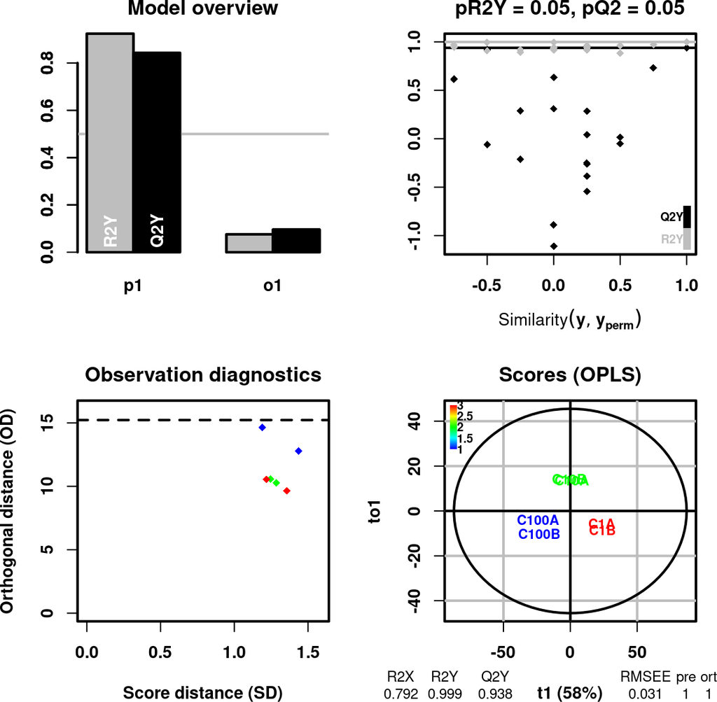

```r
plasSet.opls <- opls(t(peakTable),scale(log10(vconcentration)),predI = 1,log10L = TRUE, orthoI = NA)
```

As the variance explained Q2 is superior to 0.9, the fitted model explains the majority of the variance. The score plot and the observation diagnostic show that there as no aberrant deviation between samples. As the compounds are spiked with an increasing concentration of chemicals, this should be visible of the first components. We see that the non suppressed peak contribute the most to the data.

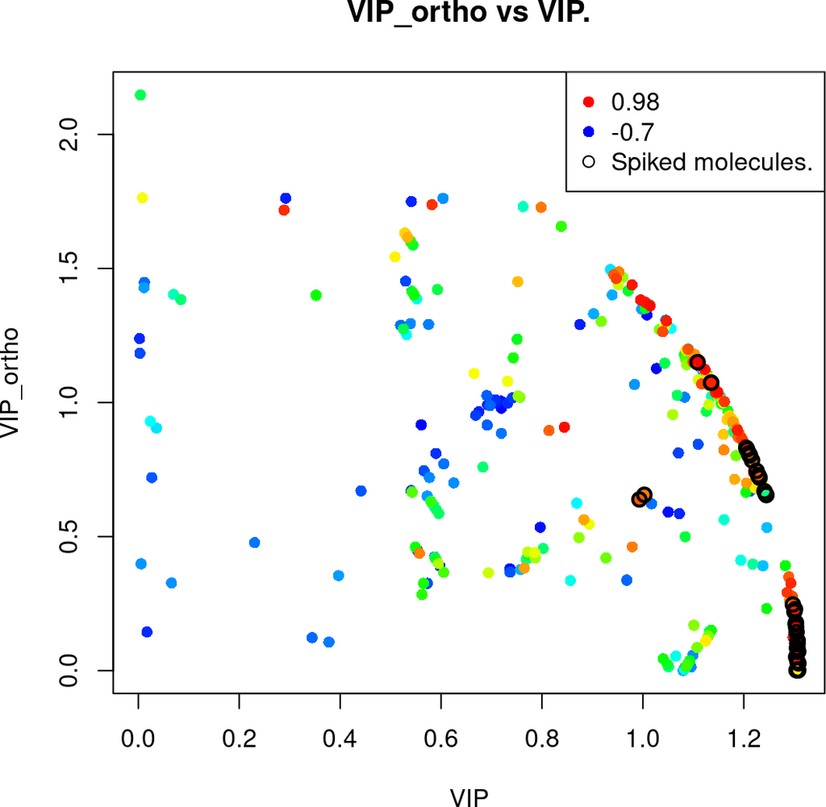

```r
matEfInd <- peakTable$corSampPeakMean
nnaVl <- !is.na(matEfInd)
matEfInd <- matEfInd[nnaVl]
ordVi <- order(matEfInd)
matEfInd <- matEfInd[ordVi]
vipVn <- getVipVn(plasSet.opls)[nnaVl]
orthoVipVn <- getVipVn(plasSet.opls, orthoL = TRUE)[nnaVl]
colVc <- rev(rainbow(sum(nnaVl), end = 4/6))
plot(vipVn[ordVi], orthoVipVn[ordVi], pch = 16, col = colVc,
     xlab = "VIP", ylab = "VIP_ortho", main = "VIP_ortho vs VIP.",lwd=3)

##Adding the point corresponding to samples.
points(getVipVn(plasSet.opls)[lMatch],getVipVn(plasSet.opls, orthoL = TRUE)[lMatch], cex=1.2,pch=1,col="black",lwd=2)
legend("topright", legend = c(round(rev(range(matEfInd)), 2),"Spiked molecules."), pch=c(16,16,1),col = c(rev(colVc[c(1, length(colVc))]),1))
```

The two clusters are probably caused by molecules naturally present in the plasma and molecules not present in the plasma.

The influence of ppm and dmz on band detection can be visualized by *plotRaw*.

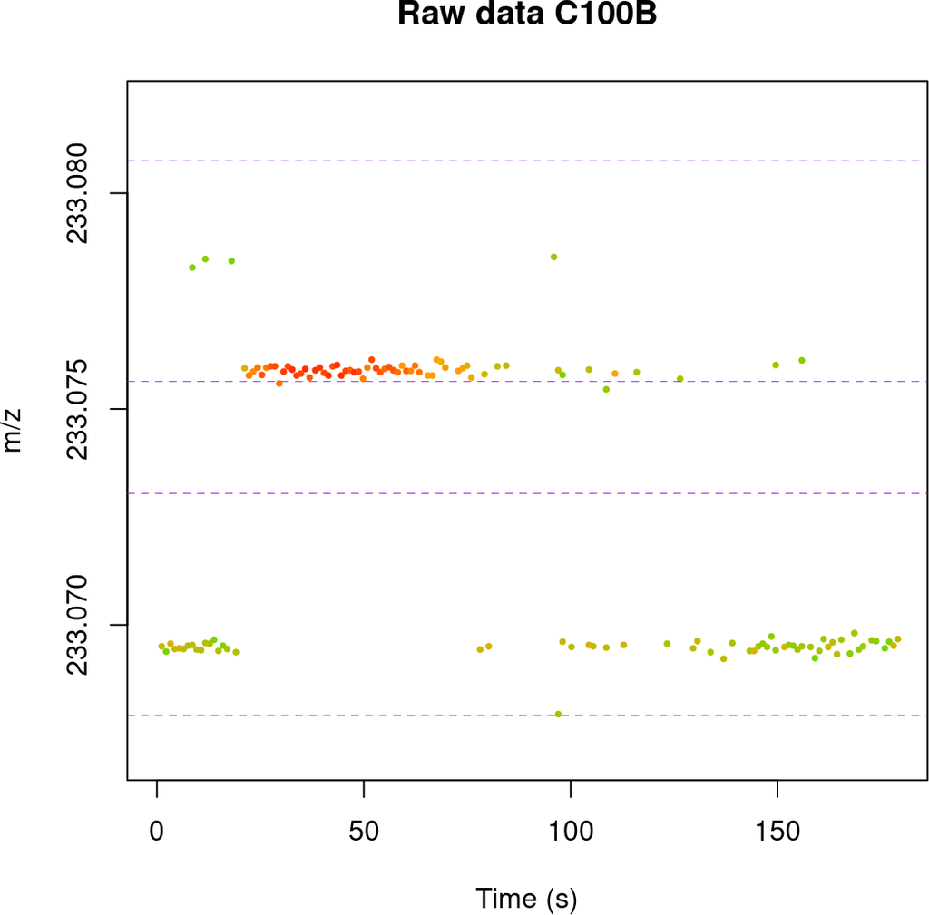

```r
##Loading the plasFIA dataset
library(plasFIA)
library(proFIA)

data(plasSet)

###Selection of the first sample file
filepath <- phenoClasses(plasSet)[1,1]
filepath

###Loading the raw data
xraw <- xcmsRaw(filepath)

#proFIAset relies on the internal findBandsFIA function to detect m/z bands. The influence of ppm and dmz values can be visualized as follows:
band_list <- findBandsFIA(xraw, ppm = 15, dmz = 0.001)
mzlim <- c(233.067,233.082)
plotRaw(plasSet,sample=2,ylim=mzlim,type="r",legend=FALSE)
abline(h=band_list[,c("mzmin","mzmax")],lwd=0.5,lty=2,col="purple")
```

Here we see that two distinct bands have been mistakenly grouped by the algorithm because the ppm value was too high. Decreasing the ppm value leads to the correct detection of the two bands:

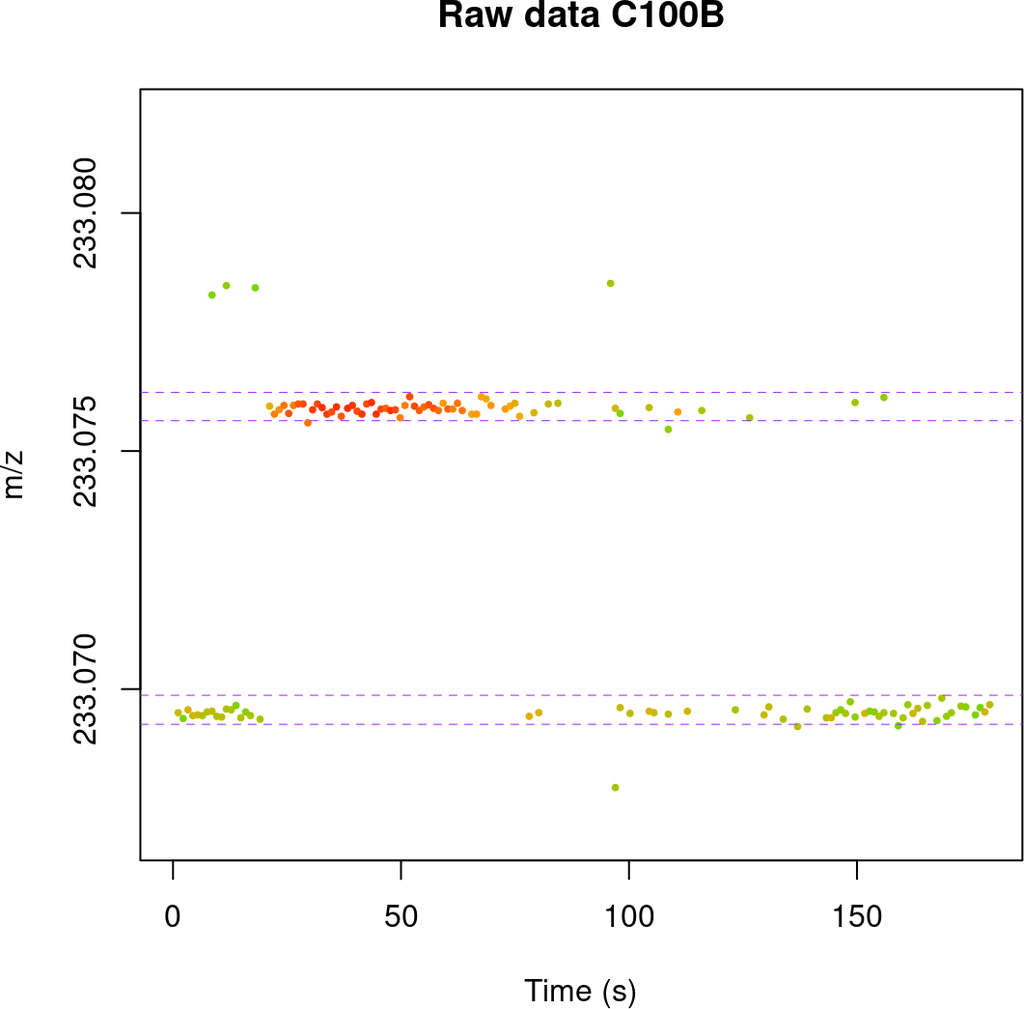

```r
band_list <- findBandsFIA(xraw, ppm = 2, dmz = 0.0005)
plotRaw(plasSet,sample=2,ylim=mzlim,type="r",legend=FALSE)
abline(h=band_list[,c("mzmin","mzmax")],lwd=0.5,lty=2,col="purple")
```

Note: Too low *dmz* values result in the absence of detected signals at low m/z, which can be checked on the “density of m/z features” graphic generated by the *plot* function

- *bandCoverage* and *sizeMin* A band is kept only if there is at least *bandCoverage* fraction of point centroids in the injection window, or if there is at least *sizeMin* consecutives points. The *bandCoverage* default value of 0.3 is adapted but may need to be increased in the presence of a long right-tailed peak originating from diffusion in the carrier flow, especially if the number of detected signals seems too high or too low. A lower values allows a better sensitivity, at the detriment of the reproductibility of peak picking.
- *pvalthresh* The pval thresh parameter is only used in case where a peak is detected with a baseline. This should not happen except if you have strong carry over between the acquisition. For example in *plasSet* dataset, a p-value is calculated on only 22 variables out of 834. The parameter value is set to 0.01 by default and, but may be tune down (to 0.001 by example) in case of noisy data with strong carry-over effect.
- Situationnal parameters These parameters should not be used in the general case, but they can be used to treat particular acquisition, which ill formed peaks or other issue
  - *scanMin* and *scanMax* The bands and peak will only be detected in the (*scanMin*,*scanMax*) range. This is useful if you have chemical noise at the beginning or at the end of your injection.
  - *f* The standard method is ‘regression’ on the most well-shaped peak , which uses the Total Injection flowgram (TIF) to define the starting values. In cases were the TIC is wrongly conditioned, this method may fail, in this case you may set f to ‘TIC’ which won’t perform the regression and directly use the TIC peak as a filter. The obtained peak will be affected by matrix effect.

The remaining arguments do not impact the detection, and are only used for intensity measurement (please see the documentation page of *findFIASignal* for their details).

- *ppmGroup* and *dmzGroup* They are similar in defintion to the *ppm* and *dmz* parameter used in the *proFIAset* function, except that they determine the bandwidth of the density taken as a parameter. As the measured mz considering for grouping are the mz of peaks, and not the m/z of individual data points, it is more accurate, we recommend to fix it to at most $ppm/2$. As described in *proFIAset* parameters settings, a tolerance in ppm is not adapted to lower m/z values so the bandwidth is taken as the minimum of the 2 tolerances. The efficiency of the grouping may be adapted using the sleep parameters to check if groups are correctly split, here is an example using two value of *ppmGroup* and *dmzGroup*

```r
plasSet <- group.FIA(plasSet,ppmGroup=5,dmzGroup=0.001,fracGroup=3/18,sleep=0.001)
```

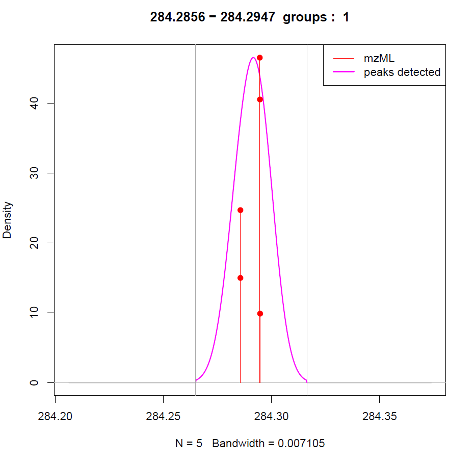

Here two distincts groups are clearly visibly and have been wrongly group. We therefore may reduce the *ppm* and *dmz* parameters :

```r
plasSet <- group.FIA(plasSet,ppmGroup=1,dmz=0.001,fracGroup=3/18,sleep=0.001)
```

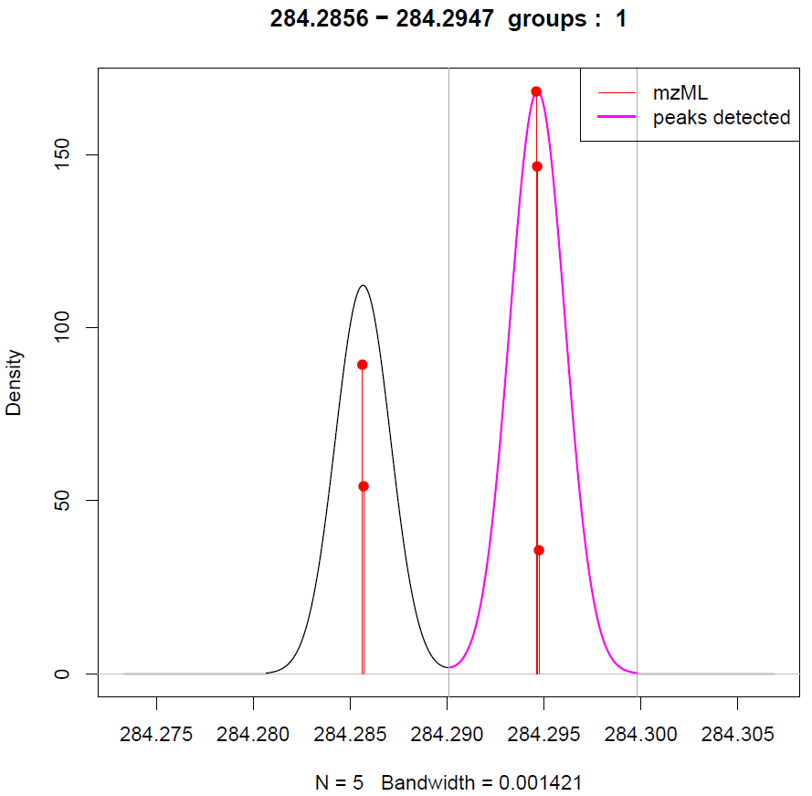

This set of parameters leads to a correct splitting of the two groups.

- *fracGroup* The *fracGroup* parameter determines in which fraction of any class a signal needs to be found to be considered as valid. It depends of your experimental setup, if your classes are homogeneous the standard value of 0.5 is a good value, this parameter may be reduced for a better sensibility.

- *KNN_TN* : A k-NN imputation using truncated distribution estimation.
  - *k* correspond to the number of neighbour. It can be a float indicating a fraction of each class.
  - *classes* how to handle imputation for different classes, if set to ‘split’, the classes are taken separately, if ‘unique’, the imputation is done on the full data matrix.’split’ is the default option and the recommended option.
- *randomForest* : A random forest imputation, the parameters are passed to the *missForest* function in the missForest package, the interested readers in invited to read the function documentation for parameters description.

```
## PCA
## 6 samples x 834 variables
## standard scaling of predictors
##       R2X(cum) pre ort
## Total    0.777   2   0
```

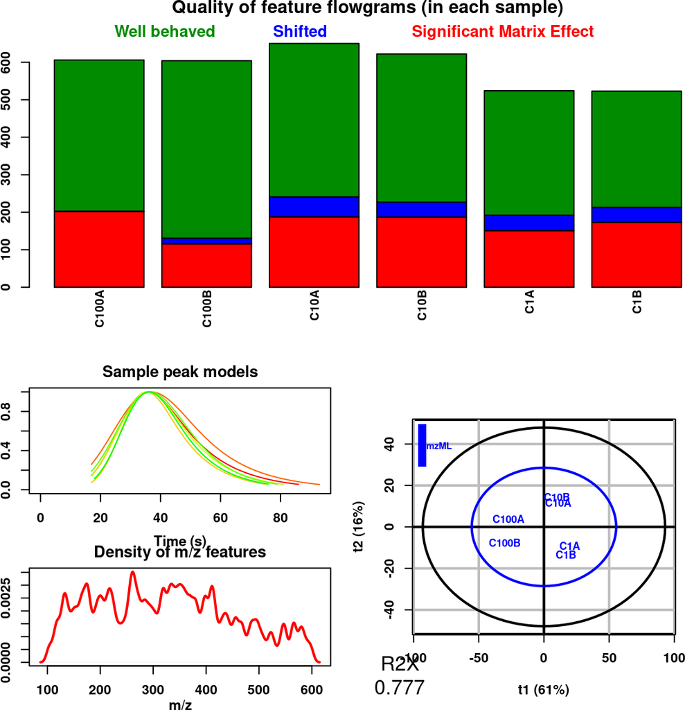

```r
data(plasSet)

###You can reset the data matrix this way
plasSet <- makeDataMatrix(plasSet)

###Before imputation.
plot(plasSet)
```

And then after imputation :

```
## PCA
## 6 samples x 834 variables
## standard scaling of predictors
##       R2X(cum) pre ort
## Total    0.827   2   0
```

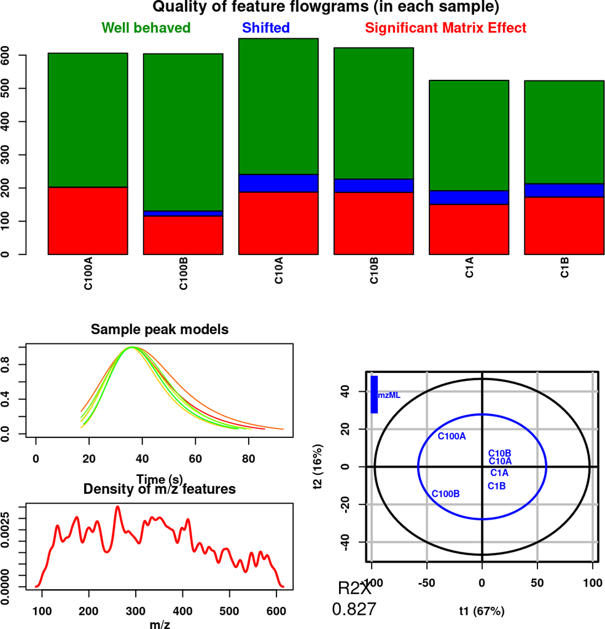

```r
plasSet <- impute.randomForest(plasSet)

###After imputation.
plot(plasSet)
```

More information on the parameters may be found in the documentation. It shall be noted that the peak picking step is the longest, so picking a small subset of data and testing various parameters, then plotting the obtained information using *plot* methods and the *plotRaw* function shloud help you to select the parameters before launching a a workflow on your full dataset.

# 6 Cheat Sheet

A pdf version of this cheat sheet is available in the *proFIA* directory :

```r
system.file(package="proFIA")
```

```
## [1] "/tmp/RtmpiEvFpK/Rinst2b4acd56ad6c5d/proFIA"
```

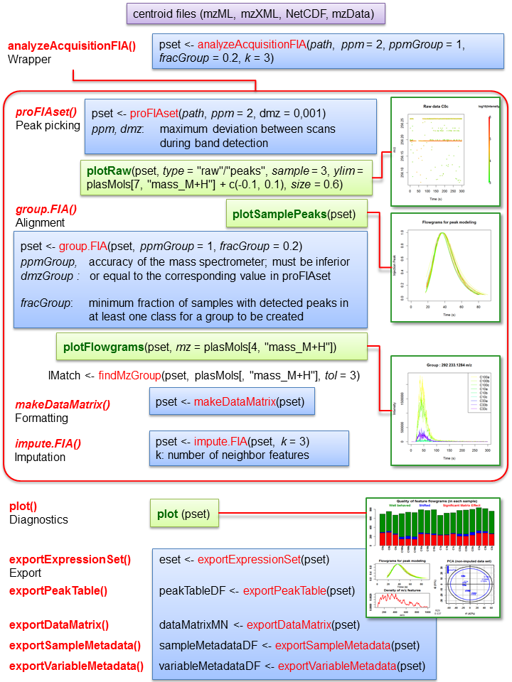

Cheat sheet

# 7 Session info